# Observer analyses (Manuscript)

Hannah, 2/19/2019

### Original subject exclusions

Data for Study 1 was collected in Fall 2015. Data for Study 2 was collected in Fall 2016.

**In Study 1:**  
- 101 subjects participated  
- 8 subjects’ AP data was discarded (see “Study1_badsubsAP.txt”)  
- 9 subjects’ WIT data was discarded (see “Study1_badsubsWIT.txt”)  
*This left 93 subjects with AP data and 92 subjects with WIT data.*

**In Study 2:**  
- 206 subjects participated  
- 8 subjects’ AP data was discarded (see “Study2_badsubsAP.txt”)  
- 7 subjects’ WIT data was discarded (see “Study2_badsubsWIT.txt”)  
*This left 198 subjects with AP data and 199 subjects with WIT data.*

There were 48 trials for each condition in each task (192 trials total for each task). In Study 2, each task was split into two sections so that participants could answer anxiety questions in the middle and end of each task.

### 1. Accuracy in each task:

#### 2 (Prime: Black/White) x 2 (Target: gun/tool or positive/negative) rANOVA

#### Study 1:

Only showing interaction indicating racial bias (Prime x Target). For calculation of effect sizes, see “7 Effect sizes.R”

**WIT**

```
##           Df Sum Sq Mean Sq F value   Pr(>F)
## ConType    1  1.251   1.251    96.5 5.97e-16 ***
## Residuals 91  1.180   0.013
## ---
## Signif. codes:  0 '***' 0.001 '**' 0.01 '*' 0.05 '.' 0.1 ' ' 1
```

**AP**

```
##           Df Sum Sq Mean Sq F value   Pr(>F)
## ConType    1 0.7788  0.7788   39.82 9.63e-09 ***
## Residuals 92 1.7992  0.0196
## ---
## Signif. codes:  0 '***' 0.001 '**' 0.01 '*' 0.05 '.' 0.1 ' ' 1
```

#### Study 2:

Only showing interaction indicating racial bias (Prime x Target). For calculation of effect sizes, see “7 Effect sizes.R”  
**WIT**

```
##            Df Sum Sq Mean Sq F value Pr(>F)
## ConType     1  1.676  1.6756   120.7 <2e-16 ***
## Residuals 198  2.748  0.0139
## ---
## Signif. codes:  0 '***' 0.001 '**' 0.01 '*' 0.05 '.' 0.1 ' ' 1
```

**AP**

```
##            Df Sum Sq Mean Sq F value   Pr(>F)
## ConType     1  1.076  1.0756   54.86 3.71e-12 ***
## Residuals 197  3.863  0.0196
## ---
## Signif. codes:  0 '***' 0.001 '**' 0.01 '*' 0.05 '.' 0.1 ' ' 1
```

### 2. Comparing responses across tasks

#### Study 1

Excludes subjects that don’t have data in both tasks (only includes sample of 90).

#### A. Correlation between performance bias scores on each task

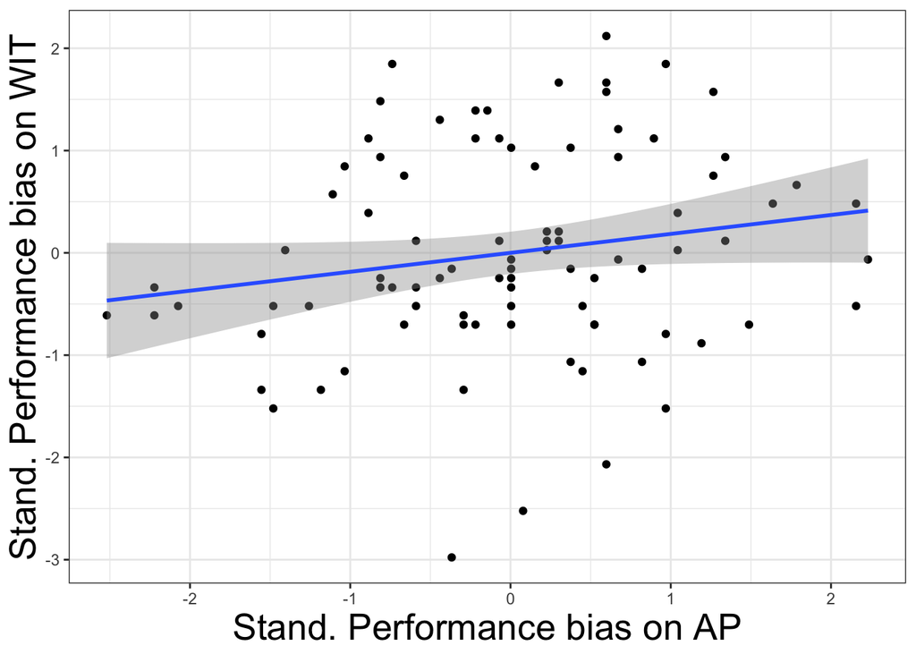

```
##
## Call:
## lm(formula = APStand ~ WITStand, data = s1.perfBias)
##
## Residuals:
##      Min       1Q   Median       3Q      Max
## -2.40625 -0.68037  0.04138  0.64697  2.25273
##
## Coefficients:
##               Estimate Std. Error t value Pr(>|t|)
## (Intercept) -1.170e-17  1.042e-01   0.000   1.0000
## WITStand     1.851e-01  1.048e-01   1.767   0.0807 .
## ---
## Signif. codes:  0 '***' 0.001 '**' 0.01 '*' 0.05 '.' 0.1 ' ' 1
##
## Residual standard error: 0.9883 on 88 degrees of freedom
## Multiple R-squared:  0.03427,    Adjusted R-squared:  0.02329
## F-statistic: 3.123 on 1 and 88 DF,  p-value: 0.08068
```

#### B. Examine 3 way Prime x Target x Task interaction

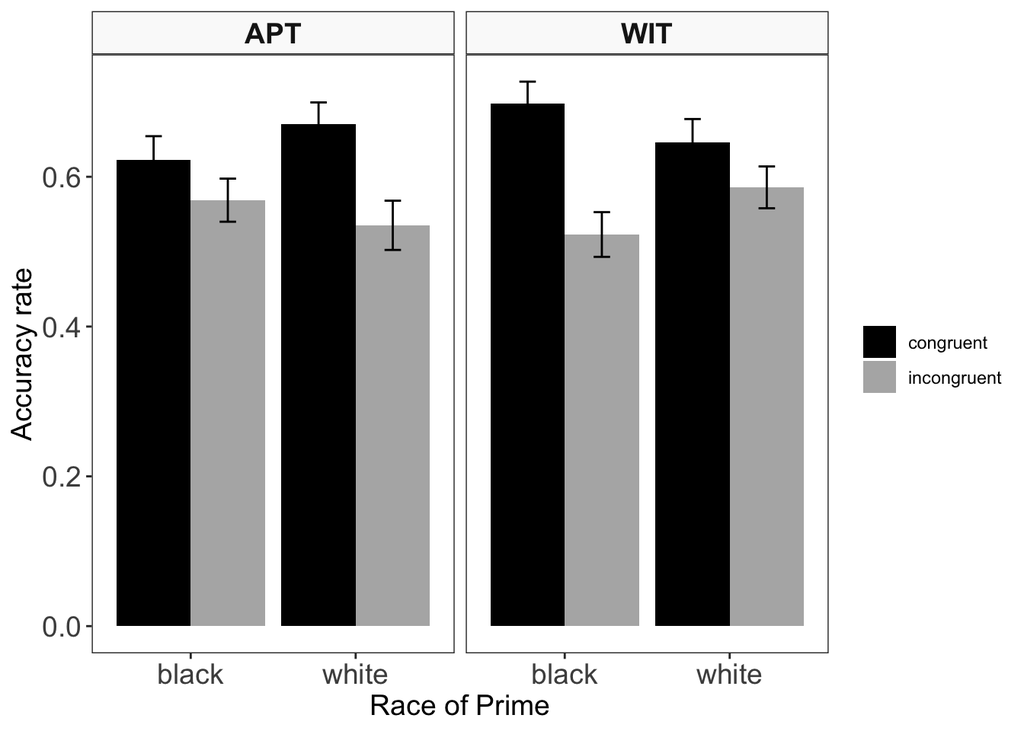

```
##                        Df Sum Sq Mean Sq F value   Pr(>F)
## PrimeType:ConType:Task  1 0.4304  0.4304   23.04 6.35e-06 ***
## Residuals              89 1.6625  0.0187
## ---
## Signif. codes:  0 '***' 0.001 '**' 0.01 '*' 0.05 '.' 0.1 ' ' 1
```

#### A. Correlation between performance bias scores on each task

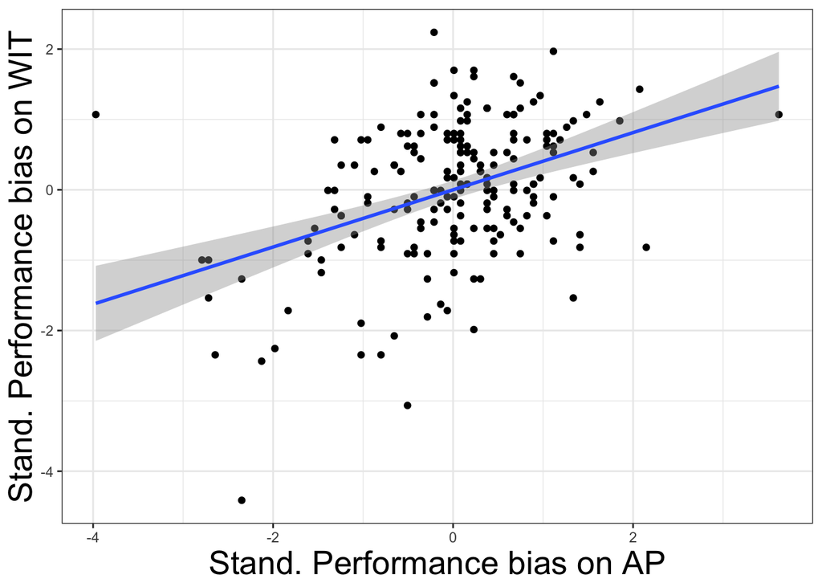

```
##
## Call:
## lm(formula = APStand ~ WITStand, data = s2.perfBias)
##
## Residuals:
##     Min      1Q  Median      3Q     Max
## -4.4047 -0.5380  0.0491  0.6008  3.1856
##
## Coefficients:
##               Estimate Std. Error t value Pr(>|t|)
## (Intercept) -7.436e-17  6.594e-02   0.000        1
## WITStand     4.065e-01  6.611e-02   6.149 4.46e-09 ***
## ---
## Signif. codes:  0 '***' 0.001 '**' 0.01 '*' 0.05 '.' 0.1 ' ' 1
##
## Residual standard error: 0.916 on 191 degrees of freedom
## Multiple R-squared:  0.1653, Adjusted R-squared:  0.1609
## F-statistic: 37.82 on 1 and 191 DF,  p-value: 4.456e-09
```

#### B. Examine 3 way Prime x Target x Task interaction

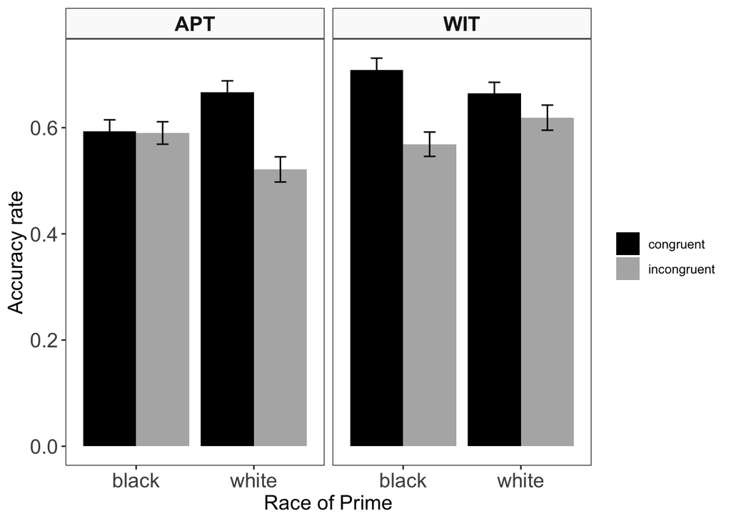

```
##                         Df Sum Sq Mean Sq F value Pr(>F)
## PrimeType:ConType:Task   1  1.356  1.3556   94.02 <2e-16 ***
## Residuals              192  2.768  0.0144
## ---
## Signif. codes:  0 '***' 0.001 '**' 0.01 '*' 0.05 '.' 0.1 ' ' 1
```

#### Compare Study 1 and Study 2

Compare magnitude of correlation between perf bias (response accuracy bias) across tasks between studies.

```
##                           Estimate Std. Error       t value   Pr(>|t|)
## (Intercept)           2.100852e-16 0.09902334  2.121572e-15 1.00000000
## WITStand              1.851160e-01 0.09957809  1.859003e+00 0.06407943
## StudyStudy2          -3.238502e-16 0.11990909 -2.700798e-15 1.00000000
## WITStand:StudyStudy2  2.214127e-01 0.12046652  1.837961e+00 0.06713131
```

### 3. Correspondance in PDP estimates across tasks

#### Study 1:

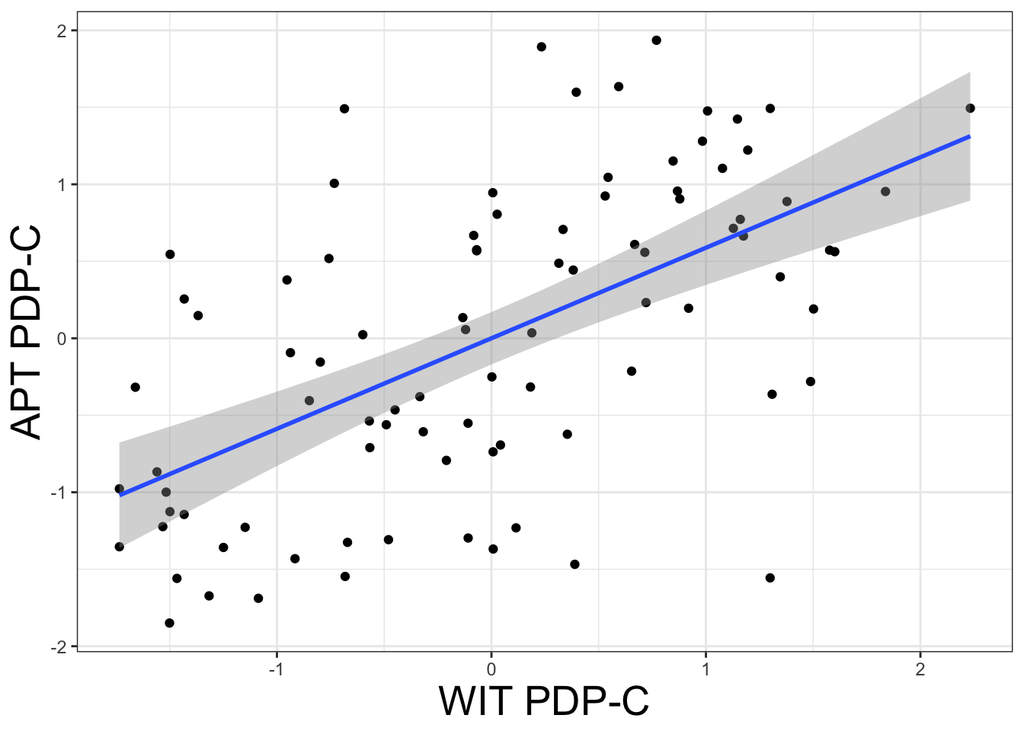

```
##
## Call:
## lm(formula = WIT.Cmean.scale ~ APT.Cmean.scale, data = s1.Cest)
##
## Residuals:
##      Min       1Q   Median       3Q      Max
## -1.81859 -0.52700  0.00726  0.44750  2.21423
##
## Coefficients:
##                   Estimate Std. Error t value Pr(>|t|)
## (Intercept)     -4.128e-17  8.575e-02   0.000        1
## APT.Cmean.scale  5.880e-01  8.623e-02   6.819 1.11e-09 ***
## ---
## Signif. codes:  0 '***' 0.001 '**' 0.01 '*' 0.05 '.' 0.1 ' ' 1
##
## Residual standard error: 0.8135 on 88 degrees of freedom
## Multiple R-squared:  0.3457, Adjusted R-squared:  0.3383
## F-statistic: 46.49 on 1 and 88 DF,  p-value: 1.109e-09
```

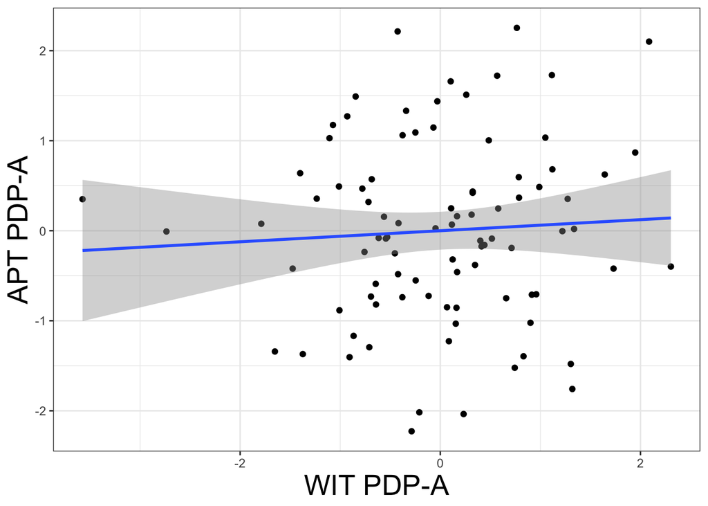

```
##
## Call:
## lm(formula = WIT.AResid.scale ~ APT.AResid.scale, data = s1.Aest)
##
## Residuals:
##     Min      1Q  Median      3Q     Max
## -3.5961 -0.6104  0.1022  0.6846  2.3282
##
## Coefficients:
##                   Estimate Std. Error t value Pr(>|t|)
## (Intercept)      2.312e-17  1.058e-01   0.000    1.000
## APT.AResid.scale 6.147e-02  1.064e-01   0.578    0.565
##
## Residual standard error: 1.004 on 88 degrees of freedom
## Multiple R-squared:  0.003778,   Adjusted R-squared:  -0.007543
## F-statistic: 0.3337 on 1 and 88 DF,  p-value: 0.5649
```

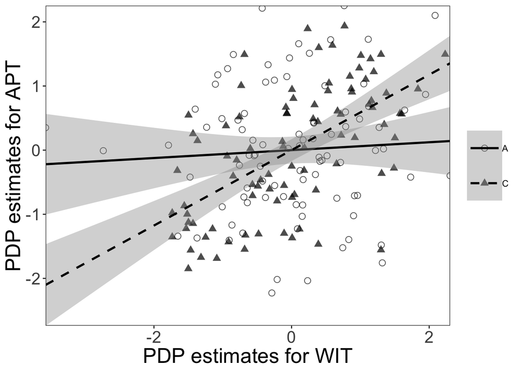

```
## lme4::lmer(formula = WIT ~ APT * EstType + (1 | Subject), data = compareAC)
```

```
##                  Estimate Std. Error        df      t value     Pr(>|t|)
## (Intercept)  5.520420e-19 0.09629148 172.41295 5.733031e-18 1.0000000000
## APT          5.616518e-02 0.09585672 173.13766 5.859284e-01 0.5586866369
## EstTypeC     7.585489e-17 0.12582323  88.15823 6.028687e-16 1.0000000000
## APT:EstTypeC 5.257701e-01 0.13299697 152.94726 3.953249e+00 0.0001175185
```

Effect size of interaction:

```
## [1] 0.1160964
```

#### Study 2:

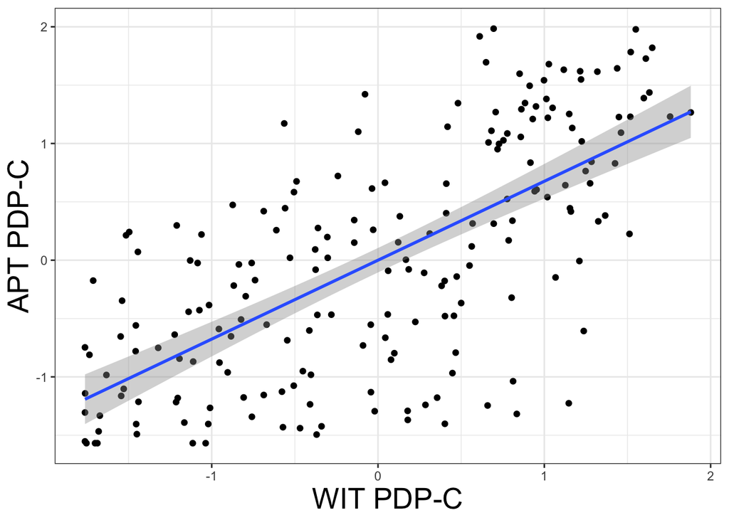

```
##
## Call:
## lm(formula = WIT.Cmean.scale ~ APT.Cmean.scale, data = s2.Cest)
##
## Residuals:
##      Min       1Q   Median       3Q      Max
## -1.65954 -0.58666  0.03517  0.54250  1.97603
##
## Coefficients:
##                  Estimate Std. Error t value Pr(>|t|)
## (Intercept)     1.880e-17  5.317e-02    0.00        1
## APT.Cmean.scale 6.762e-01  5.331e-02   12.69   <2e-16 ***
## ---
## Signif. codes:  0 '***' 0.001 '**' 0.01 '*' 0.05 '.' 0.1 ' ' 1
##
## Residual standard error: 0.7386 on 191 degrees of freedom
## Multiple R-squared:  0.4573, Adjusted R-squared:  0.4544
## F-statistic: 160.9 on 1 and 191 DF,  p-value: < 2.2e-16
```

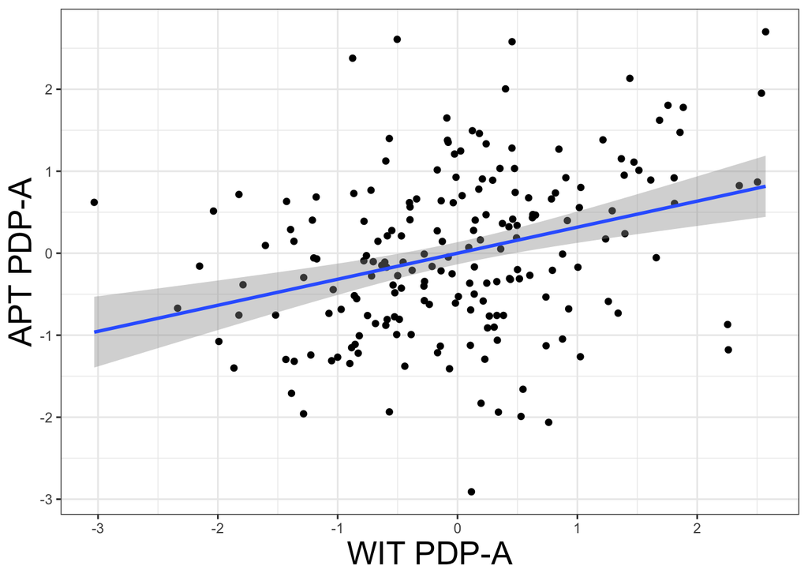

```
##
## Call:
## lm(formula = WIT.AResid.scale ~ APT.AResid.scale, data = s2.Aest)
##
## Residuals:
##     Min      1Q  Median      3Q     Max
## -3.2290 -0.5752 -0.0694  0.5920  2.6342
##
## Coefficients:
##                    Estimate Std. Error t value Pr(>|t|)
## (Intercept)      -7.102e-18  6.844e-02   0.000        1
## APT.AResid.scale  3.175e-01  6.861e-02   4.628 6.81e-06 ***
## ---
## Signif. codes:  0 '***' 0.001 '**' 0.01 '*' 0.05 '.' 0.1 ' ' 1
##
## Residual standard error: 0.9507 on 191 degrees of freedom
## Multiple R-squared:  0.1008, Adjusted R-squared:  0.09611
## F-statistic: 21.41 on 1 and 191 DF,  p-value: 6.815e-06
```

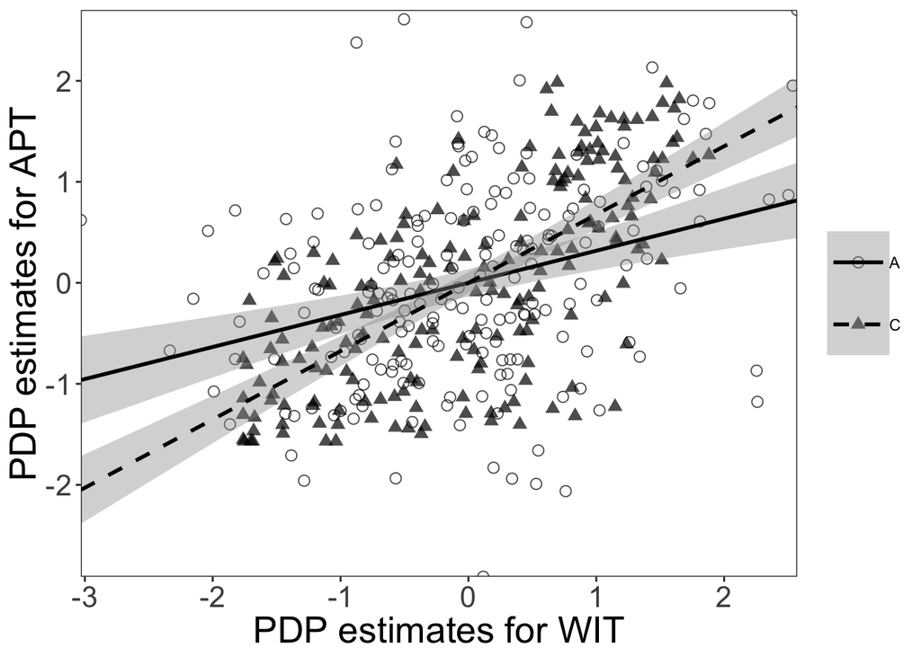

```
## lme4::lmer(formula = WIT ~ APT * EstType + (1 | Subject), data = compareAC)
```

```
##                   Estimate Std. Error       df       t value     Pr(>|t|)
## (Intercept)   4.172129e-17 0.06127980 379.8169  6.808327e-16 1.000000e+00
## APT           3.174854e-01 0.06126765 379.9593  5.181941e+00 3.573060e-07
## EstTypeC     -1.694363e-17 0.08332724 189.1376 -2.033385e-16 1.000000e+00
## APT:EstTypeC  3.488517e-01 0.08616095 363.8648  4.048838e+00 6.292215e-05
```

Effect size of interaction:

```
## [1] 0.01877576
```

#### Compare Study 1 and Study 2

Compare magnitude of correlation between PDP-A estimates across tasks between studies.

```
##                      Estimate Std. Error       t value   Pr(>|t|)
## (Intercept)     -7.752395e-16  0.1020122 -7.599476e-15 1.00000000
## WIT              6.146551e-02  0.1025837  5.991741e-01 0.54954303
## StudyStudy2      1.168391e-15  0.1235284  9.458482e-15 1.00000000
## WIT:StudyStudy2  2.560499e-01  0.1241026  2.063211e+00 0.04001762
```

Compare magnitude of correlation between PDP-C estimates across tasks between studies.

```
##                      Estimate Std. Error       t value     Pr(>|t|)
## (Intercept)     -3.215157e-16 0.08042997 -3.997461e-15 1.000000e+00
## WIT              5.879580e-01 0.08088056  7.269460e+00 3.640903e-12
## StudyStudy2      3.817737e-16 0.09739406  3.919887e-15 1.000000e+00
## WIT:StudyStudy2  8.826428e-02 0.09784681  9.020659e-01 3.677999e-01
```